# Reproducible Research - Assignment1

Sandeep Rangarajen

```r
library(ggplot2)
```

# Extracting data

I will be commenting some part when I publish as the code snippet has already been run

```r
setwd("D:/SANDY/Enter The Dragon/Data Science")
#if(!file.exists("./RERESCH")){dir.create("./RERESCH")}
#fileUrl <- "http://d396qusza40orc.cloudfront.net/repdata%2Fdata%2Factivity.zip"
#download.file(fileUrl,destfile="./RERESCH/RERESCH.zip")
## Unzip dataSet to /data directory
#unzip(zipfile="D:/SANDY/Enter The Dragon/Data Science/RERESCH/RERESCH.zip",exdir="./RERESCH")

activity_data <- read.csv("./RERESCH/activity.csv")
```

```r
 print(sum(is.na(activity_data)))
```

```
## [1] 2304
```

# What is mean total number of steps taken per day?

## – Calculate the total number of steps taken per day–

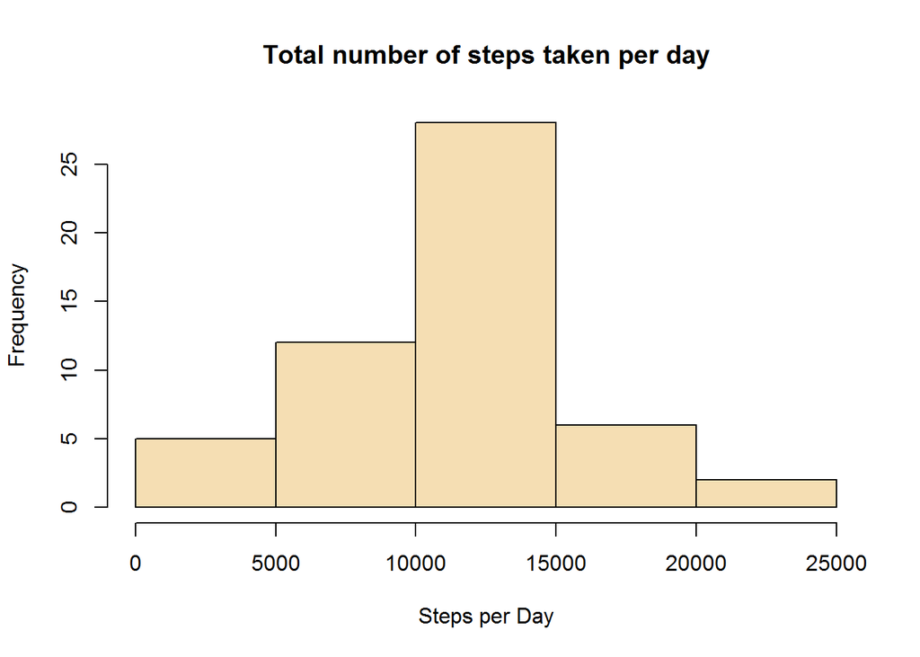

```r
activity_steps_day <- aggregate(steps ~ date, data = activity_data, FUN = sum, na.rm = TRUE)
hist(activity_steps_day$steps, xlab = "Steps per Day", main = "Total number of steps taken per day", col = "wheat")
```

# What is average number of steps taken per day?

## – Calculate the average total number of steps taken per day with a time plot

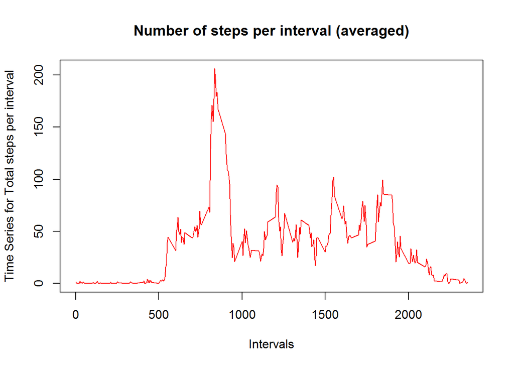

```r
activity_steps_mean <- aggregate(steps ~ interval, data = activity_data, FUN = mean, na.rm = TRUE)
##Plot the graph
plot(activity_steps_mean$interval, activity_steps_mean$steps, type = "l", col = "red", xlab = "Intervals", ylab = "Time Series for Total steps per interval", main = "Number of steps per interval (averaged)")
```

```r
#what is the highest steps value? (maximum of steps on one given interval)
max_steps <-max(activity_steps_mean$steps)
#for which interval are the numbers of steps per interval at the highest?
max_interval <- activity_steps_mean$interval[which(activity_steps_mean$steps == max_steps)]
max_steps <- round(max_steps, digits = 0)
```

```r
mean_steps <- mean(activity_steps_day$steps)
median_steps <- median(activity_steps_day$steps)

#we set a normal number format to display the results

mean_steps <- format(mean_steps,digits=1)
median_steps <- format(median_steps,digits=1)

print(mean_steps)
```

```
## [1] "10766"
```

```r
print(median_steps)
```

```
## [1] "10765"
```

# Adding Missing values

Note that there are a number of days/intervals where there are missing values (coded as NA). The presence of missing days may introduce bias into some calculations or summaries of the data.

Calculate and report the total number of missing values in the dataset (i.e. the total number of rows with NAs) There are total of 17568 Observations of which 2304 are missing values in the dataset .

Devise a strategy for filling in all of the missing values in the dataset. The strategy does not need to be sophisticated. For example, you could use the mean/median for that day, or the mean for that 5-minute interval, etc. New data set shall be calculated by assiging average values of the time interval from all days.

```r
act_temp <- activity_data
print(sum(is.na(act_temp)))
```

```
## [1] 2304
```

```r
##Missing values
nas <- is.na(act_temp$steps)

avg_interval <- tapply(act_temp$steps, act_temp$interval, mean, na.rm=TRUE, simplify=TRUE)

act_temp$steps[nas] <- avg_interval[as.character(act_temp$interval[nas])]

activity_steps_day_nas <- aggregate(steps ~ date, data = act_temp, FUN = sum, na.rm = TRUE)

head(activity_steps_day_nas)
```

```
##         date    steps
## 1 2012-10-01 10766.19
## 2 2012-10-02   126.00
## 3 2012-10-03 11352.00
## 4 2012-10-04 12116.00
## 5 2012-10-05 13294.00
## 6 2012-10-06 15420.00
```

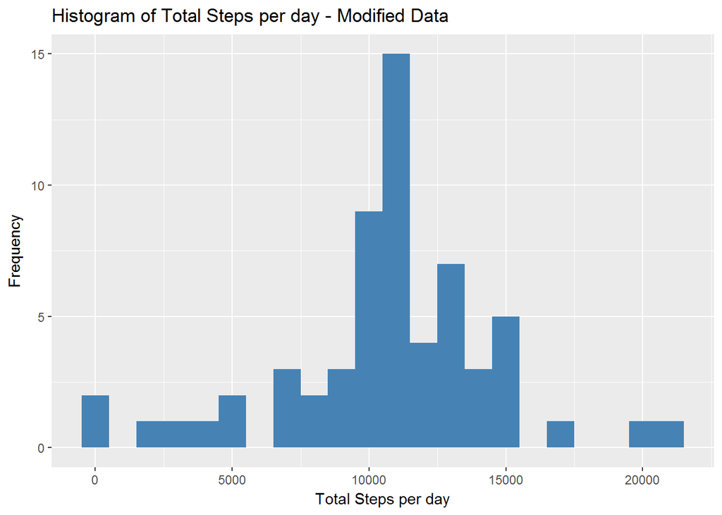

```r
mean_steps_nas <- mean(activity_steps_day_nas$steps)
median_steps_nas <- median(activity_steps_day_nas$steps)

df.activity_steps_day_nas <- as.data.frame(activity_steps_day_nas)

#Make a histogram of the total number of steps taken each day--

ggplot(df.activity_steps_day_nas, aes(x= steps))+
    geom_histogram(fill = "steelblue", binwidth = 1000)+
    labs(title = "Histogram of Total Steps per day - Modified Data", x = "Total Steps per day", y = "Frequency")
```

```r
print(mean_steps_nas)
```

```
## [1] 10766.19
```

```r
print(median_steps_nas)
```

```
## [1] 10766.19
```

## Observations on Mean and Median

The Mean and Median do not change much even after imputing the NA’s. Also the Mean and Median are equal now.

# Are there differences in activity patterns between weekdays and weekends?

### Create a new factor variable in the dataset with two levels - “Weekday” and “Weekend” indicating whether a given date is a weekday or weekend day.

```r
df.act_temp <- as.data.frame(act_temp)
df.act_temp$day <- weekdays(as.Date(act_temp$date))
df.act_temp$weekend = chron::is.weekend(df.act_temp$date)
df.act_temp$weekend[df.act_temp$weekend == "FALSE"] <- "Weekday"
df.act_temp$weekend[df.act_temp$weekend == "TRUE"] <- "Weekend"
# Doing it this way as mutate does not work on 3.3.1

DayTypeAvgSteps <- aggregate(steps ~ interval + weekend, data = df.act_temp, FUN = mean)
head(DayTypeAvgSteps)
```

```
##   interval weekend      steps
## 1        0 Weekday 2.25115304
## 2        5 Weekday 0.44528302
## 3       10 Weekday 0.17316562
## 4       15 Weekday 0.19790356
## 5       20 Weekday 0.09895178
## 6       25 Weekday 1.59035639
```

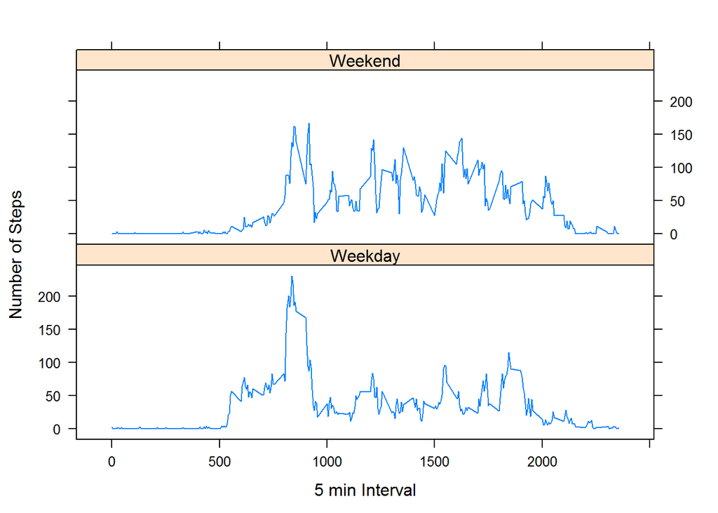

```r
df.DayTypeAvgSteps <- as.data.frame(DayTypeAvgSteps)

names(DayTypeAvgSteps) <- c("interval", "day_type", "mean_steps")

#Make a panel plot containing a time series plot (i.e. type = "l") of the 5-minute interval (x-axis) and the average number of steps taken, averaged across all weekday days or weekend days (y-axis).

library(lattice)

xyplot(mean_steps~interval|factor(day_type),
        data = DayTypeAvgSteps,
       type='l',layout=c(1,2),
       xlab='5 min Interval',ylab='Number of Steps')
```